# lab_2

# Segunda aula de laboratório, script 2[^1]

O objetivo deste roteiro de aula é apresentar exemplos de testes de significância individual, conjunta e global para regressão múltipla

## Regressões que serão estimadas

Equação de Mincer (Giuberti e Menezes-Filho, 2005; Meara, Pastore e Webster, 2020)

salário_hora_real = $\beta_0$ + $\beta_1$educação + $\beta_2$experiência + $\beta_3$setor + $\beta_4$ocupação + $\beta_5$gênero + $\beta_6$etnia + $\beta_7$região + $\beta_8$área_urbana + u<sub>t</sub>

## Dados

```r
# install.packages("tidyverse")
library(tidyverse)
load("aulas_praticas/aula_2/dados.Rdata")

# convertendo para tibbles

db_cov <- db_cov |> dplyr::as_tibble(db_cov)

db_min <- db_min |> dplyr::as_tibble(db_min)
```

Variável dependente:

- Salário-hora

Variáveis independentes:

- Educação e experiência:
  - Anos de estudo - anos_educ
  - Experiência - exper_idade_trab (idade em que começou a trabalhar)
  - Experiência ao quadrado - exper_idade_trab_sq
- Características pessoais:
  - Etnia preta ou parda - etnia_pre_par
  - Sexo masculino - d_hom
- Setor e ocupação:
  - Setor de atividade: agropecuária, indústria, construção, educação/saúde/social, outros serviços, administração pública - d_ativ*
  - Ocupação: administração, agricultura, comércio, outros serviços, dirigente, ciência/tecnologia, técnico de nível médio, reparo/manutenção, forças armadas - d_ocup*
- Regional
  - Grande região brasileiras - Nordeste (2), Sudeste (3), Sul (4), Centro Oeste (5) - d_reg_2 a d_reg_5
  - Área urbana - d_urbano

### Sumário estatístico das variáveis

```r
summary(subset(db_min, select=c(anos_educ, exper_idade_trab, exper_idade_trab_sq, d_etnia_bca_ama, d_etnia_pre_par, d_hom, d_ativ_agro, d_ativ_indus, d_ativ_const, d_ativ_social, d_ativ_serv, d_ativ_apub, d_ocup_adm, d_ocup_agro, d_ocup_com, d_ocup_serv, d_ocup_dirigente, d_ocup_cie_art, d_ocup_tec_med, d_ocup_rep_manut, d_ocup_armada, d_reg_2, d_reg_3, d_reg_4, d_reg_5, d_urbano)))
```

```
##    anos_educ      exper_idade_trab exper_idade_trab_sq d_etnia_bca_ama
##  Min.   : 0.000   Min.   : 0.0     Min.   :   0.0      Min.   :0.0000
##  1st Qu.: 6.000   1st Qu.:10.0     1st Qu.: 100.0      1st Qu.:0.0000
##  Median :11.000   Median :19.0     Median : 361.0      Median :0.0000
##  Mean   : 8.917   Mean   :19.8     Mean   : 541.3      Mean   :0.4603
##  3rd Qu.:11.000   3rd Qu.:29.0     3rd Qu.: 841.0      3rd Qu.:1.0000
##  Max.   :15.000   Max.   :59.0     Max.   :3481.0      Max.   :1.0000
##  d_etnia_pre_par      d_hom         d_ativ_agro       d_ativ_indus
##  Min.   :0.0000   Min.   :0.0000   Min.   :0.00000   Min.   :0.0000
##  1st Qu.:0.0000   1st Qu.:0.0000   1st Qu.:0.00000   1st Qu.:0.0000
##  Median :1.0000   Median :1.0000   Median :0.00000   Median :0.0000
##  Mean   :0.5397   Mean   :0.5571   Mean   :0.06467   Mean   :0.1561
##  3rd Qu.:1.0000   3rd Qu.:1.0000   3rd Qu.:0.00000   3rd Qu.:0.0000
##  Max.   :1.0000   Max.   :1.0000   Max.   :1.00000   Max.   :1.0000
##   d_ativ_const     d_ativ_social     d_ativ_serv      d_ativ_apub
##  Min.   :0.00000   Min.   :0.0000   Min.   :0.0000   Min.   :0.00000
##  1st Qu.:0.00000   1st Qu.:0.0000   1st Qu.:0.0000   1st Qu.:0.00000
##  Median :0.00000   Median :0.0000   Median :0.0000   Median :0.00000
##  Mean   :0.06236   Mean   :0.1419   Mean   :0.3978   Mean   :0.08077
##  3rd Qu.:0.00000   3rd Qu.:0.0000   3rd Qu.:1.0000   3rd Qu.:0.00000
##  Max.   :1.00000   Max.   :1.0000   Max.   :1.0000   Max.   :1.00000
##    d_ocup_adm      d_ocup_agro        d_ocup_com       d_ocup_serv
##  Min.   :0.0000   Min.   :0.00000   Min.   :0.00000   Min.   :0.0000
##  1st Qu.:0.0000   1st Qu.:0.00000   1st Qu.:0.00000   1st Qu.:0.0000
##  Median :0.0000   Median :0.00000   Median :0.00000   Median :0.0000
##  Mean   :0.1408   Mean   :0.06216   Mean   :0.07714   Mean   :0.2611
##  3rd Qu.:0.0000   3rd Qu.:0.00000   3rd Qu.:0.00000   3rd Qu.:1.0000
##  Max.   :1.0000   Max.   :1.00000   Max.   :1.00000   Max.   :1.0000
##  d_ocup_dirigente  d_ocup_cie_art    d_ocup_tec_med   d_ocup_rep_manut
##  Min.   :0.00000   Min.   :0.00000   Min.   :0.0000   Min.   :0.0000
##  1st Qu.:0.00000   1st Qu.:0.00000   1st Qu.:0.0000   1st Qu.:0.0000
##  Median :0.00000   Median :0.00000   Median :0.0000   Median :0.0000
##  Mean   :0.03126   Mean   :0.08068   Mean   :0.0919   Mean   :0.2399
##  3rd Qu.:0.00000   3rd Qu.:0.00000   3rd Qu.:0.0000   3rd Qu.:0.0000
##  Max.   :1.00000   Max.   :1.00000   Max.   :1.0000   Max.   :1.0000
##  d_ocup_armada        d_reg_2          d_reg_3          d_reg_4
##  Min.   :0.00000   Min.   :0.0000   Min.   :0.0000   Min.   :0.0000
##  1st Qu.:0.00000   1st Qu.:0.0000   1st Qu.:0.0000   1st Qu.:0.0000
##  Median :0.00000   Median :0.0000   Median :0.0000   Median :0.0000
##  Mean   :0.01473   Mean   :0.2443   Mean   :0.3324   Mean   :0.1763
##  3rd Qu.:0.00000   3rd Qu.:0.0000   3rd Qu.:1.0000   3rd Qu.:0.0000
##  Max.   :1.00000   Max.   :1.0000   Max.   :1.0000   Max.   :1.0000
##     d_reg_5          d_urbano
##  Min.   :0.0000   Min.   :0.0000
##  1st Qu.:0.0000   1st Qu.:1.0000
##  Median :0.0000   Median :1.0000
##  Mean   :0.1211   Mean   :0.9086
##  3rd Qu.:0.0000   3rd Qu.:1.0000
##  Max.   :1.0000   Max.   :1.0000
```

### Modelo em 2004

```r
# install.packages("estimatr")
library(estimatr)

db_min_2004 <- db_min |> filter(ano == 2004)

mqo <- estimatr::lm_robust(sal_hor ~ anos_educ + exper_idade_trab + exper_idade_trab_sq + d_etnia_pre_par + d_hom + d_ativ_agro + d_ativ_indus + d_ativ_const + d_ativ_social + d_ativ_serv + d_ativ_apub + d_ocup_adm + d_ocup_agro + d_ocup_com + d_ocup_serv + d_ocup_dirigente + d_ocup_cie_art + d_ocup_tec_med + d_ocup_rep_manut + d_ocup_armada + d_reg_2 + d_reg_3 + d_reg_4 + d_reg_5 + d_urbano,
                             data = db_min_2004)

summary(mqo)
```

```
##
## Call:
## estimatr::lm_robust(formula = sal_hor ~ anos_educ + exper_idade_trab +
##     exper_idade_trab_sq + d_etnia_pre_par + d_hom + d_ativ_agro +
##     d_ativ_indus + d_ativ_const + d_ativ_social + d_ativ_serv +
##     d_ativ_apub + d_ocup_adm + d_ocup_agro + d_ocup_com + d_ocup_serv +
##     d_ocup_dirigente + d_ocup_cie_art + d_ocup_tec_med + d_ocup_rep_manut +
##
## Standard error type:  HC2
##
## Coefficients:
##                      Estimate Std. Error  t value   Pr(>|t|)  CI Lower CI Upper
## (Intercept)          0.211173  5.996e-01   0.3522  7.247e-01 -0.964071  1.38642
## anos_educ            0.369292  4.467e-03  82.6687  0.000e+00  0.360537  0.37805
## exper_idade_trab     0.203126  3.440e-03  59.0400  0.000e+00  0.196383  0.20987
## exper_idade_trab_sq -0.002572  7.263e-05 -35.4160 6.413e-273 -0.002715 -0.00243
## d_etnia_pre_par     -0.635605  2.735e-02 -23.2394 3.987e-119 -0.689212 -0.58200
## d_hom                1.099752  3.021e-02  36.3988 4.772e-288  1.040533  1.15897
## d_ativ_agro         -1.509214  1.387e-01 -10.8843  1.422e-27 -1.780985 -1.23744
## d_ativ_indus        -0.331888  6.370e-02  -5.2105  1.887e-07 -0.456732 -0.20704
## d_ativ_const        -0.920635  7.252e-02 -12.6947  6.790e-37 -1.062776 -0.77849
## d_ativ_social       -0.170503  6.873e-02  -2.4807  1.312e-02 -0.305219 -0.03579
## d_ativ_serv         -0.747256  5.217e-02 -14.3233  1.755e-46 -0.849510 -0.64500
## d_ativ_apub          0.701980  8.140e-02   8.6241  6.561e-18  0.542441  0.86152
## d_ocup_adm           0.540480  5.936e-01   0.9105  3.626e-01 -0.622990  1.70395
## d_ocup_agro         -0.210188  6.061e-01  -0.3468  7.287e-01 -1.398082  0.97771
## d_ocup_com          -0.537824  5.940e-01  -0.9054  3.653e-01 -1.702143  0.62650
## d_ocup_serv         -0.783525  5.933e-01  -1.3207  1.866e-01 -1.946321  0.37927
## d_ocup_dirigente     4.071856  6.032e-01   6.7507  1.480e-11  2.889645  5.25407
## d_ocup_cie_art       4.620925  5.988e-01   7.7165  1.208e-14  3.447209  5.79464
## d_ocup_tec_med       2.171228  5.953e-01   3.6470  2.654e-04  1.004371  3.33808
## d_ocup_rep_manut    -0.137929  5.933e-01  -0.2325  8.162e-01 -1.300730  1.02487
## d_ocup_armada        3.174582  6.139e-01   5.1714  2.328e-07  1.971404  4.37776
## d_reg_2             -0.675888  4.211e-02 -16.0488  6.969e-58 -0.758432 -0.59334
## d_reg_3              0.553537  4.249e-02  13.0286  9.095e-39  0.470264  0.63681
## d_reg_4              0.425690  4.928e-02   8.6389  5.764e-18  0.329110  0.52227
## d_reg_5              0.567452  5.179e-02  10.9559  6.477e-28  0.465935  0.66897
## d_urbano             0.439815  3.847e-02  11.4317  3.042e-30  0.364408  0.51522
##                        DF
## (Intercept)         93080
```

[output cut: 13 more lines]

```
## d_ocup_com          93080
## d_ocup_serv         93080
## d_ocup_dirigente    93080
## d_ocup_cie_art      93080
## d_ocup_tec_med      93080
## d_ocup_rep_manut    93080
## d_ocup_armada       93080
## d_reg_2             93080
## d_reg_3             93080
## d_reg_4             93080
## d_reg_5             93080
## d_urbano            93080
##
## Multiple R-squared:  0.3932 ,    Adjusted R-squared:  0.393
## F-statistic:  1679 on 25 and 93080 DF,  p-value: < 2.2e-16
```

- `Multiple R-squared`: R<sup>2</sup> para uma regressão de n variáveis
- `Adjusted R-squared`: R<sup>2</sup> ajustado
- `F-statistic`: estatística de teste de significância global

### Teste de significância individual: educação

$H_0: \beta_k=0\ vs\ H_1: \beta_k \ne 0$

Estatística de teste individual: $\hat t = \beta_k/\text{erro padrão}$

```r
tmqo <- broom::tidy(mqo)

tmqo |> dplyr::slice(2) |>
  dplyr::select(term, estimate) |>
  dplyr::rename(`2004` = estimate)
```

```
##        term      2004
## 1 anos_educ 0.3692921
```

```r
View(vcov(mqo))
```

É correto que alguns elementos da matriz de variância-covariância sejam negativos? *R: Sim, pois a covariância pode ser negativa.*

```r
# install.packages("raster")
library("raster")
```

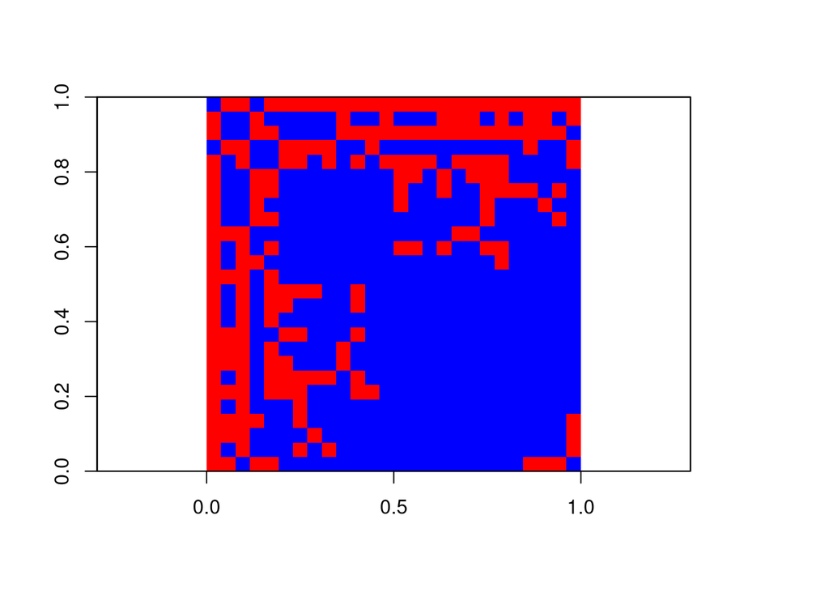

```r
colfunc <- colorRampPalette(c("red", "blue"))

plot(raster(vcov(mqo)),
     col = colfunc(2),
     breaks = c(min(vcov(mqo)),
                0,
                max(vcov(mqo))),
     legend = F,
     xlim = c(0, 1),
     ylim = c(0, 1))
```

Qual estatística está na diagonal principal da matriz de variância-covariância? *R: A variância.*

O primeiro padrão notório é que há apenas números positivos na diagonal principal. Por que isso? *R: Porque os valores na diagonal principal representam as variâncias, que não assumem valores negativos.*

A implicação do primeiro padrão é que os números negativos estão fora da diagonal principal. É correto isso? O que temos fora da diagonal principal da matriz? *R: Sim, é correto. Fora da diagonal principal temos as covariâncias.*

Notar a simetria em torno da diagonal principal (ou seja, a diagonal principal é como um espelho). Será que uma matriz de covariância-variância é sempre simétrica? *R: Sim, pois essa matriz tem os mesmos termos tanto nas linhas e como nas colunas.*

Por ex., a variância do estimador para o coeficiente da primeira explicativa, educação, é:

```r
diag(vcov(mqo))[2]
```

```
##    anos_educ
## 1.995528e-05
```

Estatística t:

```r
# estatística de teste

t <- coef(mqo)[2] / sqrt(diag(vcov(mqo))[2])

t
```

```
## anos_educ
##  82.66868
```

```r
# n da regressão para 2004

n <- nrow(subset(db_min,ano == 2004))

# n parâmetros

k <- length(coef(mqo))

# graus de liberdade

gl <- n-(k+1)

# valores críticos

c(qt(0.025, gl), qt(0.975, gl))
```

```
## [1] -1.959989  1.959989
```

RC: $(-\infty;-1{,}96]\cup[1{,}96; -\infty)$

```r
# p-valor

2*pt(-abs(t),gl)
```

```
## anos_educ
##         0
```

Ao se rejeitar H<sub>0</sub>, pode-se afirmar que `anos_educ` é uma variável diferente de 0 a uma significância de 5%.

### Teste de significância global

```r
summary(mqo)
```

```
##
## Call:
## estimatr::lm_robust(formula = sal_hor ~ anos_educ + exper_idade_trab +
##     exper_idade_trab_sq + d_etnia_pre_par + d_hom + d_ativ_agro +
##     d_ativ_indus + d_ativ_const + d_ativ_social + d_ativ_serv +
##     d_ativ_apub + d_ocup_adm + d_ocup_agro + d_ocup_com + d_ocup_serv +
##     d_ocup_dirigente + d_ocup_cie_art + d_ocup_tec_med + d_ocup_rep_manut +
##
## Standard error type:  HC2
##
## Coefficients:
##                      Estimate Std. Error  t value   Pr(>|t|)  CI Lower CI Upper
## (Intercept)          0.211173  5.996e-01   0.3522  7.247e-01 -0.964071  1.38642
## anos_educ            0.369292  4.467e-03  82.6687  0.000e+00  0.360537  0.37805
## exper_idade_trab     0.203126  3.440e-03  59.0400  0.000e+00  0.196383  0.20987
## exper_idade_trab_sq -0.002572  7.263e-05 -35.4160 6.413e-273 -0.002715 -0.00243
## d_etnia_pre_par     -0.635605  2.735e-02 -23.2394 3.987e-119 -0.689212 -0.58200
## d_hom                1.099752  3.021e-02  36.3988 4.772e-288  1.040533  1.15897
## d_ativ_agro         -1.509214  1.387e-01 -10.8843  1.422e-27 -1.780985 -1.23744
## d_ativ_indus        -0.331888  6.370e-02  -5.2105  1.887e-07 -0.456732 -0.20704
## d_ativ_const        -0.920635  7.252e-02 -12.6947  6.790e-37 -1.062776 -0.77849
## d_ativ_social       -0.170503  6.873e-02  -2.4807  1.312e-02 -0.305219 -0.03579
## d_ativ_serv         -0.747256  5.217e-02 -14.3233  1.755e-46 -0.849510 -0.64500
## d_ativ_apub          0.701980  8.140e-02   8.6241  6.561e-18  0.542441  0.86152
## d_ocup_adm           0.540480  5.936e-01   0.9105  3.626e-01 -0.622990  1.70395
## d_ocup_agro         -0.210188  6.061e-01  -0.3468  7.287e-01 -1.398082  0.97771
## d_ocup_com          -0.537824  5.940e-01  -0.9054  3.653e-01 -1.702143  0.62650
## d_ocup_serv         -0.783525  5.933e-01  -1.3207  1.866e-01 -1.946321  0.37927
## d_ocup_dirigente     4.071856  6.032e-01   6.7507  1.480e-11  2.889645  5.25407
## d_ocup_cie_art       4.620925  5.988e-01   7.7165  1.208e-14  3.447209  5.79464
## d_ocup_tec_med       2.171228  5.953e-01   3.6470  2.654e-04  1.004371  3.33808
## d_ocup_rep_manut    -0.137929  5.933e-01  -0.2325  8.162e-01 -1.300730  1.02487
## d_ocup_armada        3.174582  6.139e-01   5.1714  2.328e-07  1.971404  4.37776
## d_reg_2             -0.675888  4.211e-02 -16.0488  6.969e-58 -0.758432 -0.59334
## d_reg_3              0.553537  4.249e-02  13.0286  9.095e-39  0.470264  0.63681
## d_reg_4              0.425690  4.928e-02   8.6389  5.764e-18  0.329110  0.52227
## d_reg_5              0.567452  5.179e-02  10.9559  6.477e-28  0.465935  0.66897
## d_urbano             0.439815  3.847e-02  11.4317  3.042e-30  0.364408  0.51522
##                        DF
## (Intercept)         93080
```

[output cut: 13 more lines]

```
## d_ocup_com          93080
## d_ocup_serv         93080
## d_ocup_dirigente    93080
## d_ocup_cie_art      93080
## d_ocup_tec_med      93080
## d_ocup_rep_manut    93080
## d_ocup_armada       93080
## d_reg_2             93080
## d_reg_3             93080
## d_reg_4             93080
## d_reg_5             93080
## d_urbano            93080
##
## Multiple R-squared:  0.3932 ,    Adjusted R-squared:  0.393
## F-statistic:  1679 on 25 and 93080 DF,  p-value: < 2.2e-16
```

```r
# R^2

r2 <- 0.3932

# graus de liberdade (K)

gl_num <- length(coef(mqo))-1

# graus de liberdade [N-(K+1)]

gl_den <- nrow(subset(db_min, ano == 2004)) - length(coef(mqo))

# estatística de teste

f <- (r2 / gl_num) / ((1 - r2) / gl_den)

f
```

```
## [1] 2412.594
```

```r
# p-valor

pf(f, gl_num, gl_den, lower.tail = F)
```

```
## [1] 0
```

Ao se rejeitar H<sub>0</sub>, pode-se afirmar que o modelo é relevante para explicar o modelo a uma significância de 5%.

### Teste de significância conjunta

Estatística de teste: $\hat F = \frac{(SQR_R-SQR_{IR})/s}{SQR_{IR}/(N-K-1)}$

```r
# regressão restrita

formula_R <- sal_hor ~ anos_educ + exper_idade_trab + exper_idade_trab_sq + d_etnia_pre_par + d_hom + d_reg_2 + d_reg_3 + d_reg_4 + d_reg_5 + d_urbano

mqo_R <- lm(formula_R,
            data = subset(db_min,
                          ano == 2004))

SQR_R <- sum(mqo_R$residuals^2)

SQR_IR <- sum(mqo$residuals^2)

# diferença entre o número de parâmetros entre os dois modelos (número de explicativas alvo - s)

s <- length(coef(mqo))-length(coef(mqo_R))

f1 <- ((SQR_R - SQR_IR) / s) / (SQR_IR / gl_den)

f1
```

```
## [1] Inf
```

```r
# p-valor

pf(f1, s, gl_den, lower.tail = F)
```

```
## [1] 0
```

Ao se rejeitar H<sub>0</sub>, pode-se afirmar que as variáveis selecionadas no teste de significância conjunta são relevantes para o modelo.

### Intervalos de confiança para coeficientes

```r
# IC a 95% de confiança

c(t + qt(0.025, gl_den) * sqrt(diag(vcov(mqo))[2]), t - qt(0.025, gl_den) * sqrt(diag(vcov(mqo))[2]))
```

```
## anos_educ anos_educ
##  82.65993  82.67744
```

# Referências

GIUBERTI, A. C.; MENEZES-FILHO, N. Discriminação de rendimentos por gênero: uma comparação entre o Brasil e os Estados Unidos. **Economia Aplicada**, v. 9, p. 369–384, set. 2005.

MEARA, K.; PASTORE, F.; WEBSTER, A. The gender pay gap in the USA: a matching study. **Journal of Population Economics**, v. 33, n. 1, p. 271–305, 1 jan. 2020.

[^1]: Preparado por Thiago Fonseca Morello (CECS-UFABC).